# Exploratory Data Analysis - HW 1

## Importing libraries

```python
import numpy as np
import pandas as pd
from matplotlib import pyplot as plt
import seaborn as sns
import statsmodels.api as sm
import scipy.stats as stats
from sklearn.preprocessing import LabelEncoder
import copy
sns.set()
```

## 1. Read in the data set and perform preliminary checks

```python
# read the dataset
df = pd.read_csv("MedTrial.csv")
print(df)

classes = pd.unique(df['Med'])
num_classes = len(classes)
each_class = df['Med'].value_counts()

print(classes)
print(num_classes)
print(each_class)

print(df.info())
```

```
     Age Sex      BP Cholesterol  Na_to_K       Med
0     23   F    HIGH        HIGH   25.355     Yipic
1     47   M     LOW        HIGH   13.093  Comodify
2     47   M     LOW        HIGH   10.114  Comodify
3     28   F  NORMAL        HIGH    7.798   Xlenify
4     61   F     LOW        HIGH   18.043     Yipic
..   ...  ..     ...         ...      ...       ...
195   56   F     LOW        HIGH   11.567  Comodify
196   16   M     LOW        HIGH   12.006  Comodify
197   52   M  NORMAL        HIGH    9.894   Xlenify
198   23   M  NORMAL      NORMAL   14.020   Xlenify
199   40   F     LOW      NORMAL   11.349   Xlenify

[200 rows x 6 columns]
['Yipic' 'Comodify' 'Xlenify' 'Abelify' 'Bulity']
5
Yipic       91
Xlenify     54
Abelify     23
Comodify    16
Bulity      16
Name: Med, dtype: int64
<class 'pandas.core.frame.DataFrame'>
RangeIndex: 200 entries, 0 to 199
Data columns (total 6 columns):
 #   Column       Non-Null Count  Dtype
---  ------       --------------  -----
 0   Age          200 non-null    int64
 1   Sex          200 non-null    object
 2   BP           200 non-null    object
 3   Cholesterol  200 non-null    object
 4   Na_to_K      200 non-null    float64
 5   Med          200 non-null    object
dtypes: float64(1), int64(1), object(4)
memory usage: 9.5+ KB
None
```

### Answers to questions

**How many samples do we have?** There are 200 samples (0-indexed, so 199+1 = 200 total samples from the dataset output)

**How many features do we have?** We have five features total

**What are the classes?** I'm assuming that this CSV file/datset is structured in the same way as ICHW1. That is, the classes are in the last column of the dataset, with the features in the preceding columns. The classes, therefore, would be the kind of medication that the patient is on. Here, that would be Yipic, Comodify, Xlenify, Abelify, and Bulity.

**How many classes do we have?** Five (see the output below the array that starts with `['Yipic' 'Comodify'`, etc.)

**How many samples of each class? are they balanced?** Yipic: 91 Xlenify: 54 Abelify: 23 Comodify: 16 Bulity: 16

Because some classes have more than others (i.e. Yipic has many more samples than Bulity), these classes are not balanced.

## 2. Check missing values, outliers and statistics

```python
df.isna().apply(pd.value_counts)
```

|  | Age | Sex | BP | Cholesterol | Na_to_K | Med |
| --- | --- | --- | --- | --- | --- | --- |
| False | 200 | 200 | 200 | 200 | 200 | 200 |

### Answers to questions

**Are there any missing values?** No. Since the previous line returned `False`, there are no values that are missing. Therefore, nothing needs to be done. To get rid of outliers.

**Are there anomolies in the statistics?** Yes. As can be seen in the boxplot below, only the continuous values of Age and Na_to_K are plotted. It would make the most sense to change the features like BP from "NORMAL", "HIGH", and "LOW" to a numerical scheme. I'll do that below the boxplot.

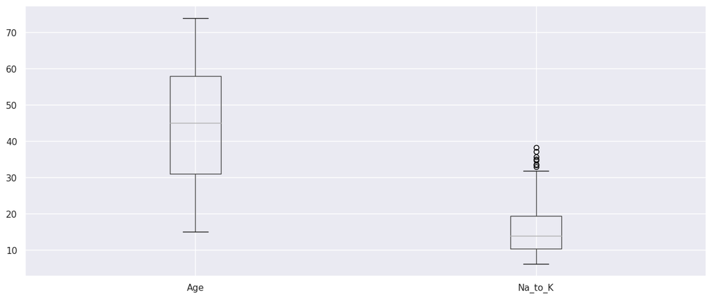

|  | count | mean | std | min | 25% | 50% | 75% | max |
| --- | --- | --- | --- | --- | --- | --- | --- | --- |
| Age | 200.0 | 44.315000 | 16.544315 | 15.000 | 31.0000 | 45.0000 | 58.00 | 74.000 |
| Na_to_K | 200.0 | 16.084485 | 7.223956 | 6.269 | 10.4455 | 13.9365 | 19.38 | 38.247 |

```python
df.boxplot(figsize = (15,6))
plt.show()
df.describe().T
```

Changes to make to the dataset:

1. Change the "Sex" column to the following:

"M": 0 "F": 1

2. Change the "BP" column to the following:

"LOW": 0 "NORMAL": 1 "HIGH": 2

3. Change the "Cholesterol" column to the following:

"LOW": 0 "NORMAL": 1 "HIGH": 2

```python
# Implementing step 1
sex_dict = {"M": 0, "F": 1}
df['Sex'] = df['Sex'].replace(sex_dict)

# Implementing step 2
bp_dict = {"LOW": 0, "NORMAL": 1, "HIGH": 2}
df['BP'] = df['BP'].replace(bp_dict)

# Implementing step 3
chol_dict = {"LOW": 0, "NORMAL": 1, "HIGH": 2}
df['Cholesterol'] = df['Cholesterol'].replace(chol_dict)

# Implementing step 4
percentile = 19.38
df.loc[df['Na_to_K'] >= percentile, 'Na_to_K'] = percentile
```

## 3. Check distributions and coorelations

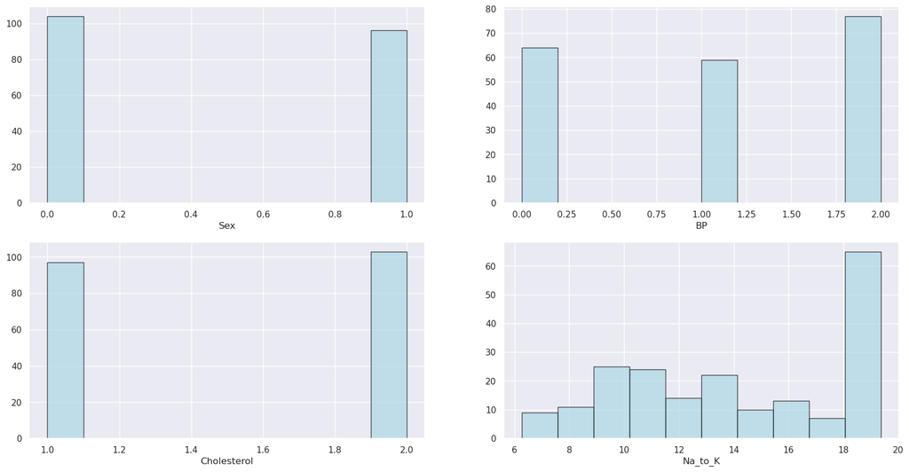

```python
plt.figure(figsize= (20,10))
plt.subplot(2, 2, 1)
plt.hist(df['Sex'], color='lightblue', edgecolor = 'black', alpha = 0.7)
plt.xlabel('Sex')

plt.subplot(2, 2, 2)
plt.hist(df['BP'], color='lightblue', edgecolor = 'black', alpha = 0.7)
plt.xlabel('BP')

plt.subplot(2,2,3)
plt.hist(df['Cholesterol'], color='lightblue', edgecolor = 'black', alpha = 0.7)
plt.xlabel('Cholesterol')

plt.subplot(2,2,4)
plt.hist(df['Na_to_K'], color='lightblue', edgecolor = 'black', alpha = 0.7)
plt.xlabel('Na_to_K')
plt.show()
```

### Answers to questions

**What kind of distributions do the features have?**

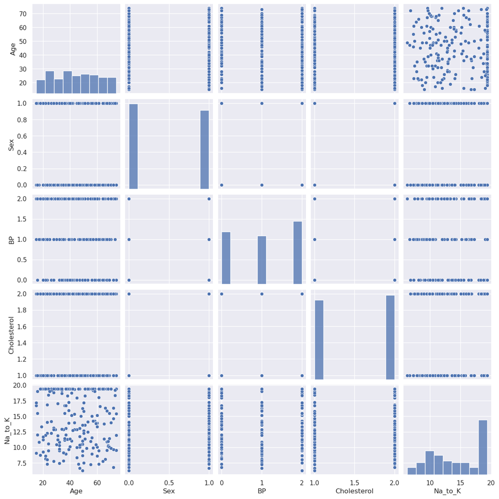

```python
sns.pairplot(df)  #pairplot
plt.show()
```

### Answers to questions

**What kind of correlation does the data exhibit?**

It doesn't appear that there is any strong correlation within the data. This can be seen both by the scatter plot above but also by the heatmap below.

```python
df.corr()
```

|  | Age | Sex | BP | Cholesterol | Na_to_K |
| --- | --- | --- | --- | --- | --- |
| Age | 1.000000 | -0.102027 | -0.120918 | 0.068234 | -0.043854 |
| Sex | -0.102027 | 1.000000 | 0.044952 | -0.008811 | 0.140351 |
| BP | -0.120918 | 0.044952 | 1.000000 | -0.032208 | 0.037017 |
| Cholesterol | 0.068234 | -0.008811 | -0.032208 | 1.000000 | 0.018142 |
| Na_to_K | -0.043854 | 0.140351 | 0.037017 | 0.018142 | 1.000000 |

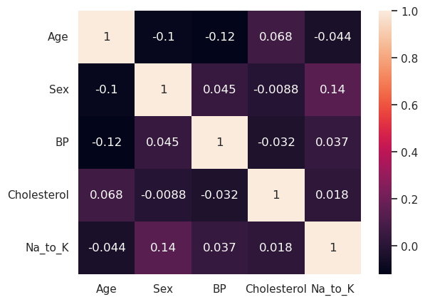

```python
sns.heatmap(df.corr(), annot = True)
plt.show()
```